# Proyecto final. Datamining.

### Análisis tweets UEFA Champions League Final 2018

### Participantes:

Gonzalo de las Heras de Matías - Jorge de la Fuente Tagarro - Alejandro Amarillas Cámara - Sergio Sampio Balmaseda.

### Notebook (2/4). Estadísticas Generales.

### Objetivo del notebook:

Este notebook se centra en mostrar estadísticas generales acerca de los tweets.

[figure not shown]

#### Librerias

```python
import pandas as pd
import numpy as np
import matplotlib.pyplot as plt
import gmaps
import gmaps.datasets
import gmaps.geojson_geometries
from collections import Counter
from Library.Apriori import APriori
from wordcloud import WordCloud, STOPWORDS
from matplotlib.cm import viridis
from matplotlib.colors import to_hex

pd.options.display.max_colwidth = 500
gmaps.configure(api_key="AIzaSyChafUDb00RYZ7y7wsZKhgslvQXSDudURQ")
```

#### Funciones

```python
def RGB(Minimo, Maximo, Valor):
    """
    Función que calcula el valor RGB para el mapa de calor.
    """
    Minimo, Maximo = float(Minimo), float(Maximo)
    ratio = 2 * (Valor-Minimo) / (Maximo - Minimo)
    b = int(max(0, 255*(1 - ratio)))
    r = int(max(0, 255*(ratio - 1)))
    g = 255 - b - r
    return r, g, b
```

#### Carga de datos

```python
Datos = pd.read_json("datos_limpios.json")
print("Hay", len(Datos), "registros")
```

```
Hay 330384 registros
```

Desgranamos la hora de cada tweet para poder agrupar más fácilmente.

```python
Datos["hora"] = pd.to_datetime(Datos["hora"])
Datos["min"] = Datos["hora"].dt.minute
Datos["hour"] = Datos["hora"].dt.hour
del Datos["hora"]
```

Eliminamos 61 registros que son antes del partido a una hora distanciada de la hora del partido.

```python
Datos = Datos[Datos["hour"] > 15]
print("Hay", len(Datos), "registros")
```

```
Hay 330323 registros
```

# 1.- Cantidad de tweets

En total hay más de 330.000 tweets.

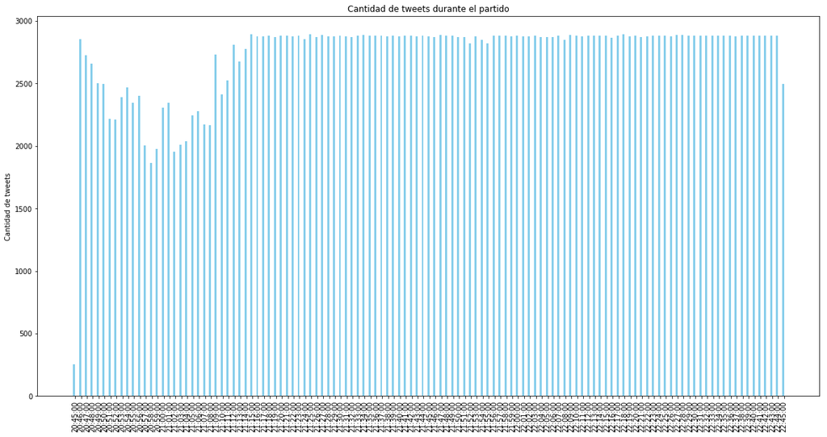

```python
# Extraemos los campos necesarios y agrupamos por hora y minuto.
horas = Datos[['hour', 'min']]
horas = horas.groupby(['hour', 'min']).size().reset_index(name='counts')
horas["hora_str"] = ""
horas["hora"] = ""

# Creamos las etiquetas para la gráfica.
for index, row in horas.iterrows():
    if row["min"] < 10:
        minutos = "0" + str(row["min"])
    else:
        minutos = str(row["min"])
    horas.loc[index, "hora_str"] = str(row["hour"]) + ":" +minutos
    horas.loc[index, "hora"] = str(row["hour"]) + ":" + minutos + ":00"

# Preparamos la gráfica.
ind = np.arange(len(horas))
ancho = 0.35
fig, ax = plt.subplots(figsize=(20, 10))
rects1 = ax.bar(ind - ancho/2, horas["counts"], ancho, color='SkyBlue')
ax.set_ylabel('Cantidad de tweets')
ax.set_title('Cantidad de tweets durante el partido')
ax.set_xticks(ind)
ax.set_xticklabels(horas["hora"])
plt.xticks(rotation=90)

# Mostramos la gráfica.
plt.show()
```

Vemos que durante el comienzo del partido, que no ocurrió nada reseñable, los tweets acerca de la final son bajos. Sin embargo, desde el incidente con Sergio Ramos, la cantidad de tweets se dispara (hasta alcanzar el máximo número de tweets que podemos obtener gratuitamente de la API de Twitter).

# 2.- Fuente de los tweets

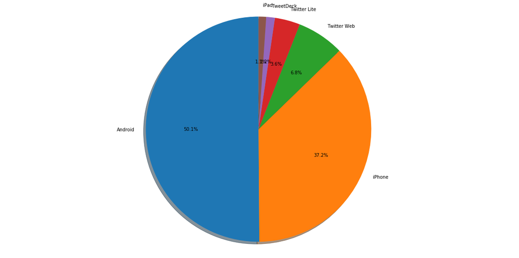

```python
Fuente = Datos["fuente"]
Fuente = pd.DataFrame(Fuente.value_counts()).reset_index()
Fuente = Fuente[Fuente["fuente"] > 3000]
Fuente.head()
fig, ax = plt.subplots(figsize=(20, 10))
ax.pie(Fuente["fuente"], labels=Fuente["index"], autopct='%1.1f%%', shadow=True, startangle=90)
ax.axis('equal')
plt.show()
```

# 3.- Países/Idiomas

Cargamos el dataset de paises y su correspondencia en idioma.

```python
DatosPaises = pd.read_csv("paises.csv", sep=";")
```

Agrupamos para calcular el número de tweets de cada país.

```python
# Capturamos los campos requeridos.
IdiomasPaises = Datos[['usuario_idioma']]
IdiomasPaises = IdiomasPaises.groupby(['usuario_idioma']).size().reset_index(name='counts')
IdiomasPaises["usuario_idioma"] = IdiomasPaises["usuario_idioma"].str.lower()
IdiomasPaises["pais"] = ""
IdiomasPaises = IdiomasPaises.reset_index(drop=True)

# Preprocesamos el nombre de cada país e idioma para poder cruzar datasets.
for index, row in IdiomasPaises.iterrows():
    pais = DatosPaises[DatosPaises["idioma"] == row["usuario_idioma"]]["pais"]
    if len(pais) > 0:
        if row["usuario_idioma"] == "en-gb":
            IdiomasPaises.loc[index, "usuario_idioma"] = "en"
        IdiomasPaises.loc[index, "pais"] = pais.values[0]

# Eliminamos los registros de los que no sepamos qué país es.
IdiomasPaises = IdiomasPaises[IdiomasPaises["pais"] != ""]
IdiomasPaises = IdiomasPaises.reset_index(drop=True)

# Borramos el campo innecesario.
del IdiomasPaises["usuario_idioma"]

# Agrupos y contamos.
IdiomasPaises = IdiomasPaises.groupby(['pais']).sum().reset_index()
IdiomasPaises
```

|  | pais | counts |
| --- | --- | --- |
| 0 | Catalonia | 1062 |
| 1 | Denmark | 170 |
| 2 | France | 13185 |
| 3 | Germany | 7258 |
| 4 | Greece | 1811 |
| 5 | Indonesia | 4089 |
| 6 | Italy | 6835 |
| 7 | Japan | 4884 |
| 8 | Netherlands | 1248 |
| 9 | Poland | 1583 |
| 10 | Portugal | 19531 |
| 11 | Russia | 1175 |
| 12 | Spain | 49442 |
| 13 | Thailand | 3859 |
| 14 | Turkey | 5653 |
| 15 | Ukraine | 284 |
| 16 | United Arab Emirates | 6995 |
| 17 | United Kingdom | 199323 |

## 3.1.- Mapa de calor

```python
# Cargamos la geometría de cada país.
paises_geojson = gmaps.geojson_geometries.load_geometry('countries')

# Cálculo de valores para normalizar valores.
min_val = min(IdiomasPaises["counts"])
max_val = max(IdiomasPaises["counts"])
rango = max_val - min_val

# Calculamos cada color para el mapa de calor.
colores = []
for feature in paises_geojson['features']:
    nombre_pais = feature['properties']['name']
    try:
        if nombre_pais in IdiomasPaises["pais"].values:
            # Extraemos del dataset el nº de tweets.
            numTweets = IdiomasPaises[IdiomasPaises["pais"] == nombre_pais]["counts"].values[0]
            # Calculamos el color.
            r,g,b = RGB(min_val, max_val, numTweets)
            # Lo parseamos el formato correcto.
            color = (r, g , b, 1)
        else:
            color = (0,0,0,0)
    except KeyError:
        print("Error")
        color = (0, 0, 0, 0)
    colores.append(color)

# Creamos el mapa.
fig = gmaps.figure()
capa = gmaps.geojson_layer(
    paises_geojson,
    fill_color=colores,
    stroke_color=colores,
    fill_opacity=0.8)

# Añadimos la capa y mostramos el mapa.
fig.add_layer(capa)
fig
```

[output not shown]

Observamos como los países que más tweets han escrito son aquellos de los participantes en la final. También sale Portugal, aunque en mucho menos medida. Esto se debe al seguimiento masivo que provoca en su país Cristiano Ronaldo.

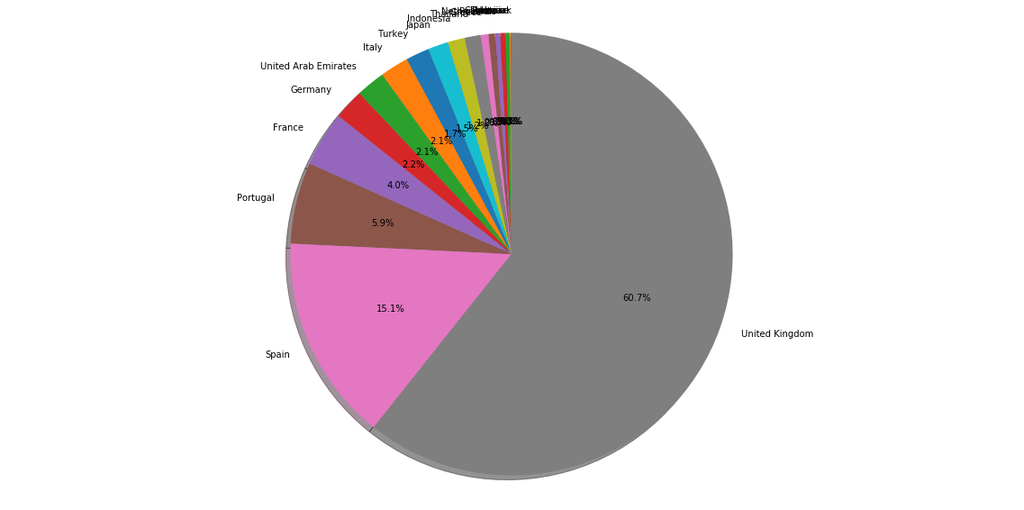

```python
IdiomasPaises  = IdiomasPaises.sort_values(["counts"])
fig, ax = plt.subplots(figsize=(20, 10))
ax.pie(IdiomasPaises["counts"], labels=IdiomasPaises["pais"], autopct='%1.1f%%', shadow=True, startangle=90)
ax.axis('equal')
plt.show()
```

Llama la atención los Emiratos Árabes. Aunque es un país sin mucha tradición futbolística, cada vez más se va introduciendo en el fútbol. Prueba de ello, es como jugadores famosos juegan en sus últimos años en este país.

# Referencias

- https://www.kaggle.com/xvivancos/tweets-during-r-madrid-vs-liverpool-ucl-2018
- https://github.com/pbugnion/gmaps
- https://pandas.pydata.org/
- Apuntes de la asignatura